# TP II IFSBM UE 12: Big Data and predictive models

Introduction to deep learning.

Loic Verlingue, Md, PhDc loic.verlingue@gustaveroussy.fr

Yoann Pradat, PhDc yoann.pradat@centralesupelec.fr

29 January, 2023

[figure not shown]

# 1. What you will do in this R Notebook

## 1. Introduction

This is the second day of your training in R for Machine Learning. You will now enter the wide, wild and exciting field of Deep Learning! Neural Networks and Deep Learning have revolutionized the performance of many Machine Learning tasks in image analysis, video analysis, natural language processing and many other “traditional” classification, regression or clustering tasks.

As for the first lab, you will be dealing with a huge amount of variables (genes expression per patient) compared to the number of patients. You again would like to **provide the clinician with a simple output** that he can use for his patients.

## 1.2 Main steps

In this notebook, you will be guided through TCGA data and images from the MNIST data. From expression data we will try to implement a neural network to perform classification tasks while from images we will also implement a (convolutional) neural network to also perform classification.

Neural networks and machine learning are at the heart of current innovations! To go further, join us for exciting research projects!

## 1.3 In practice

The code is provided to you. You will just have to follow the instructions all along the notebook. Explanations and corrections will be given throughout the notebook for a subset of the questions.

**IMPORTANT** There are questions in this notebook that you need to answer and code that you need to write by yourself during the lab or at home. The questions are indicated by a tag “QUESTION” while the code you need to write is indicated by a tag “INCLASS WORK”.

# 2. Build your first neural network with Keras.

## 2.1 About Keras.

[Keras](https://keras.io/) is a Python deep learning library designed to help human build and train neural networks of many different types. It builds on top of [Tensorflow 2](https://www.tensorflow.org/), an end-to-end open source platform for machine leanring. The Keras has an R interface through the [Keras R package](https://keras.rstudio.com/) which will be using in this lab.

The math is pre-computed, and functions are relatively user-friendly: is a high level API. It can use several lower level back-ends for the math and calculation. Keras and Tensorflow have been develloped by Google and are open source.

```r
library(keras)
use_condaenv(condaenv="ifsbm_tp2")
```

You can check with the command `conda info --envs` run from a command line interface that an environment named `ifsbm_tp2` exists. If not, read the instructions from the README. After running this cell, restart your R studio. Check that your installation is correct by verifying that the next chunk does not return an error.

```r
model <- keras_model_sequential()
```

For the next steps we will be using some `R` libraries. Load them with the following

```r
library(RColorBrewer)
library(dplyr)
library(knitr)
library(tidyr)
library(yarrr)
```

We will also use some useful functions.

```r
getColors <- function(vec, pal="Dark2", alpha=0.7){
  colors <- list()

  palette_predefined <- read.csv("../data/colors.csv")
  palette_predefined <- setNames(palette_predefined$Color, palette_predefined$Name)
  palette_default <- brewer.pal(max(length(unique(vec)),3), pal)
  i <- 1
  for (v in unique(vec)){
    if (toupper(v) %in% names(palette_predefined)){
      colors[[as.character(v)]] <- adjustcolor(palette_predefined[[toupper(v)]], alpha)
    } else {
      colors[[as.character(v)]] <- adjustcolor(palette_default[[i]], alpha)
      i <- i+1
    }
  }
  colors
}

getConfusionMatrix <- function(labelsPredicted, labelsCorrect, labels=NULL){
  if (is.null(labels)){
    labels <- sort(unique(union(labelsPredicted, labelsCorrect)))
  } else {
    labels <- sort(unique(labels))
  }
  confMat <- data.frame(row.names=labels)

  for (labelPredicted in labels){
    for (labelCorrect in labels){
      confMat[labelPredicted, labelCorrect] <- sum(labelsPredicted==labelPredicted & labelsCorrect==labelCorrect)
    }
  }

  confMat
}
```

## 2.2 Load the data

As in the previous lab, we will be using data from the TCGA project. More specifically we will continue to load expression data restricted to genes from the Cancer Gene Census.

```r
source("../../lib/LoadcBioportal.R")
```

```
## Please send questions to cbioportal@googlegroups.com
```

```r
CgcTable <- read.csv("../data/CancerGeneCensusCOSMIC_20230117.csv")
CgcGenes <- CgcTable$Gene.Symbol

TcgaData <- LoadcBioportal(Organ="luad_tcga_pan_can_atlas_2018|lusc_tcga_pan_can_atlas_2018",
                           Genes=CgcGenes,
                           ClinicNeeded=T,
                           MutNeeded=F,
                           MutExtNeeded=F,
                           RNANeeded=T,
                           NormalizeRNA=T)
```

```
## [1] "Pooling : luad_tcga_pan_can_atlas_2018 & lusc_tcga_pan_can_atlas_2018"
```

```r
print(table(TcgaData$CLINIC$study))
```

```
##
## luad lusc
##  503  466
```

```r
colorsStudy <- getColors(TcgaData$CLINIC$study, alpha=0.7)
TcgaData$CLINIC$study_num <- ifelse(TcgaData$CLINIC$study=="luad", 0, 1)
```

## 2.3. Visualize your data

As already explained in the previous lab, it is an important step than visualizing your data and performing some vanilla analyses. Let us reproduce the same plots as for the `blca|lusc` comparison.

**The distribution plot**

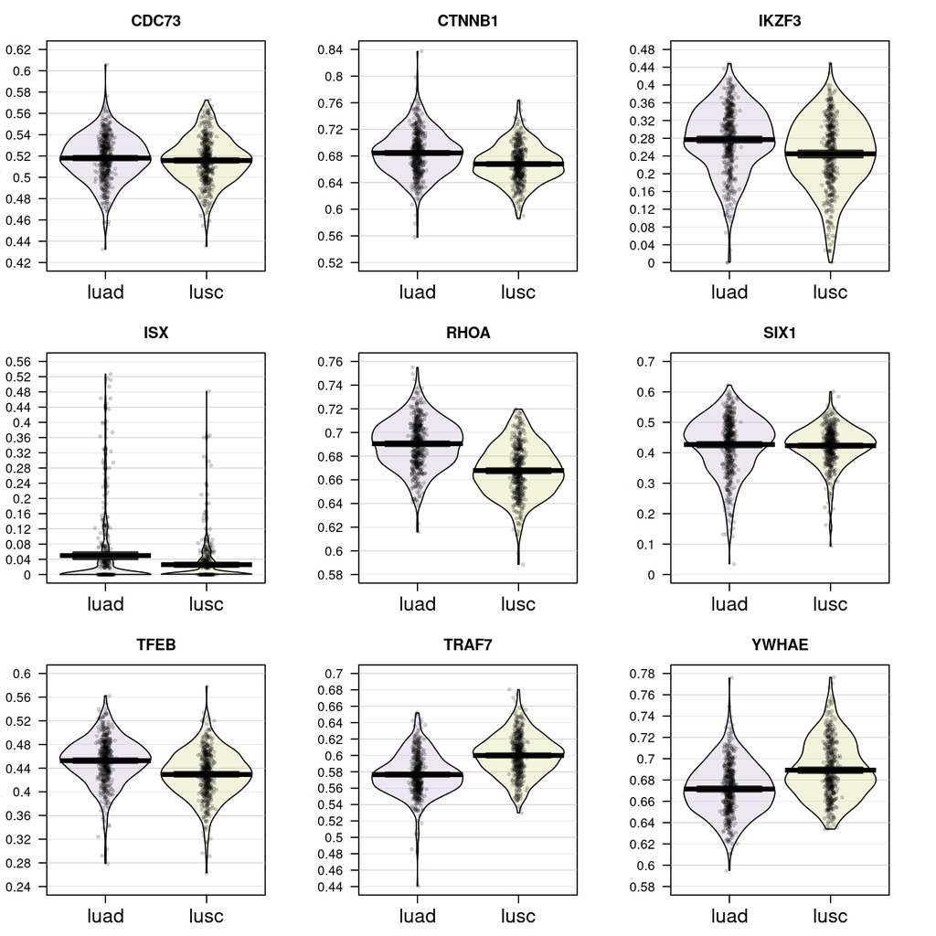

Genes expressions

```r
set.seed(1995)
colorsStudy <- getColors(TcgaData$CLINIC$study, alpha=1)
genesExp <- colnames(TcgaData$EXP)
genesHist <- sort(sample(genesExp, size=9, replace=F))
par(mfrow=c(3,3), mai=c(0.35,0.4,0.35,0.4))

for (geneHist in genesHist){
  mask_luad <- TcgaData$CLINIC$study=="luad"
  mask_lusc <- TcgaData$CLINIC$study=="lusc"
  DataGene <- rbind(data.frame(Expression=TcgaData$EXP[mask_luad,geneHist], Tumor="luad"),
                    data.frame(Expression=TcgaData$EXP[mask_lusc,geneHist], Tumor="lusc"))

  pirateplot(formula=Expression ~ Tumor,
             data=DataGene,
             theme=1,
             quant=NULL,
             pal=colorsStudy,
             main=geneHist,
             xlab="")
}
```

**The heatmap plot**

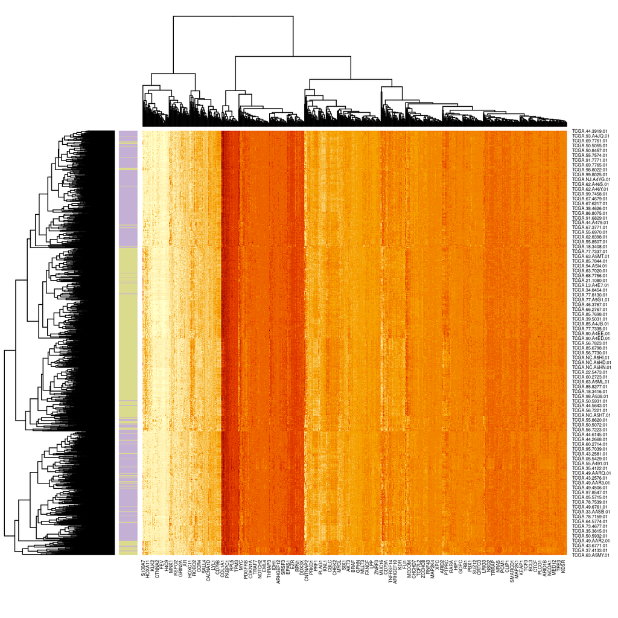

TCGA expression data LUAD and LUSC

```r
rowNames <- rownames(TcgaData$EXP)
rowStudy <- TcgaData$CLINIC[rowNames, "study"]
rowSideColors <- sapply(rowStudy, function(x) colorsStudy[[x]])
heatmap(as.matrix(TcgaData$EXP), Rowv=NULL, Colv=NULL, keep.dendro=F, RowSideColors=rowSideColors)
```

**The PCA plot**

```r
X <- t(t(TcgaData$EXP) - rowMeans(t(TcgaData$EXP)))
resSVD <- svd(X, nu=2, nv=2)
# the scores are the principal components i.e the
# low-dimensional representations of the samples
scores <- resSVD$u %*% diag(resSVD$d[1:2])
```

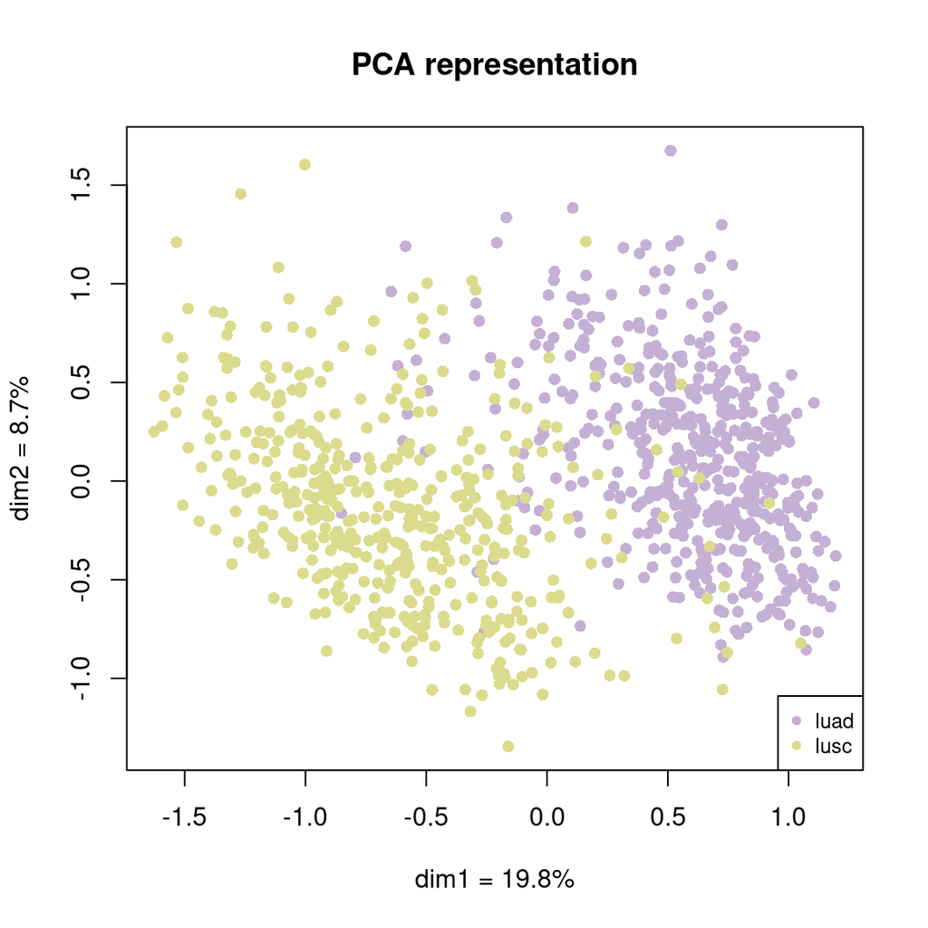

PCA TCGA expression data LUAD and LUSC

```r
# plot the two first principal components
plot(scores[,1],scores[,2],
     col=unlist(colorsStudy[TcgaData$CLINIC$study]),
     pch=16,main='PCA representation',
     xlab=paste("dim1 = ",100*round(resSVD$d[1]^2/sum(resSVD$d^2),3),"%",sep = ""),
     ylab=paste("dim2 = ",100*round(resSVD$d[2]^2/sum(resSVD$d^2),3),"%",sep = ""))
legend("bottomright",legend=c("luad","lusc"), pch=16, cex=0.8, col=c(colorsStudy[["luad"]], colorsStudy[["lusc"]]))
```

## 2.4 Build a neural network

### Train/test split

For the purpose of assessing correctly the generalization capabilities of our future model we split the data into a train and a test part.

```r
studySize <- nrow(TcgaData$CLINIC)
trainProp <- 0.8
trainIndex <- sample(seq(studySize), size=round(studySize*trainProp))
testIndex <-seq(studySize)[!seq(studySize) %in% trainIndex]

print(paste("Training size:", length(trainIndex)))
```

```
## [1] "Training size: 775"
```

```r
print(paste("Test size:", length(testIndex)))
```

```
## [1] "Test size: 194"
```

### Model building

Building the neural network means building individual layers and connecting them through different methods. Once your have build your network, you can compile and then fit it on the data.

The basic building block of a neural network is the **layer**. Layers sequentially learn representations of the data fed into them and outputs their new representation to the following layer until the last layer tha provides a representation suitable for performing a given tasks.

**INCLASS WORK** Define a neural network by defining a sequence of dense layers. For this first exercice, you have build a network with only one hidden layer. The input layer should take as input a vector of size the number of genes in the `TcgaData$EXP` table while the output layer should produce a 2D vector of “class conditional probabilities” (neural networks outputs are not in general probabilities).

*Hint*: In order to build your first model you will need the following functions 1. `keras_model_sequential` to initialize the model object. 2. `layer_dense` to create dense layers (i.e fully connected).

You may find information in the [online documentation](https://cran.r-project.org/web/packages/keras/keras.pdf) of the R keras package.

```r
input_shape <- ncol(TcgaData$EXP)

model <- keras_model_sequential()
model %>%
 layer_dense(input_shape = input_shape, units = 128, activation = 'relu') %>%
 layer_dense(units = 30, activation = 'relu') %>%
 layer_dense(units = 1, activation = 'sigmoid'
             )
# 1 hidden couche et 1 couche de sortie
```

You can visualize your model architecture by just printing the model as in the following chunk

```r
print(model)
```

**QUESTION 1)** What does the `activation` parameter represent in the `layer_dense` function from keras? Give example values for this parameter.

**ANSWER**:The activation parameter is used to specify the activation function to be applied to the output of the dense layer. The goal of activation function is to introduce non-linearity into a neural network, allowing it to learn more complex relationships between inputs and outputs. The activation function is applied element-wise to the output of the dense layer before it is passed on to the next layer. The classical activation function are RELU, Softmax, Tanh, sigmoïd…

### Compile the model

Before the model is ready for training, it needs a few more settings. These are added during the model’s compilation step. In particular, you need to specify the following

1. **The loss function** - This measures how accurate the model is during training. We want to minimize this function to “steer” the model in the right direction. Careful designing of the loss function allows to train networks with specific properties (regularized for instance).
2. **Optimizer** - This is the numerical methods used to update the network’s weights so as to minimize the loss function.
3. **Metrics** - Used to monitor the training and testing steps. The following example uses accuracy, the fraction of the samples that are correctly classified.

**INCLASS WORK** Apply the compilation step on your model by specifying the parameters mentioned above. You should use `adam` as an optimizer, `binary_crossentropy` as a loss function and `accuracy` as a metric.

*Hint*: Look into [this example](https://tensorflow.rstudio.com/guide/keras/) and into the documentation of the `compile` function.

```r
model %>% compile(
  optimizer = "adam",
  loss = "binary_crossentropy",
  metrics = "accuracy"
  )


#### YOUR WORK HERE
```

### Train your network

In order to train your neural network, you will have to provide it with the training data (predictive variables and predicted variable) as well as extra parameters specifiying the `validation_split` for assessing the model performance during the training, the number of `epochs` or the batch size.

**QUESTION 2)** What are epochs? What is the batch size? What could be the advantage of reducing or increasing the batch size?

**ANSWER**: Epochs is the number of times the data will be run. That is to say that we will go over each batch several times. The size of the batch is the size of the grouping of data by batch. Increasing the batch size allows us to have a faster training model but reducing it allows us to have more training because more data is processed.

A very nice way to visualize the evolution of the network accuracy is through the learning curves which may take multiple forms. In particular, one type of learning curve is the plotting of the score of your model as it moves through the epochs. You can do this plot very simply by applying the `plot` function on the `history` object produced by the `fit` function from the previous chunk.

**INCLASS WORK:** Use the `fit` method to train your neural network on the training data and draw the learning curves. Train it on 50 epochs using a validation split of 20%.

```r
model %>% fit(as.matrix(TcgaData$EXP[trainIndex,]), TcgaData$CLINIC$study_num[trainIndex], epochs = 50,validation_split=0.2)

#### YOUR WORK HERE
```

## Evaluate accuracy

Next, compare how the model performs on the test dataset:

**INCLASS WORK** Use the `evaluate` method to evaluate the quality of your neural network on test data. How does it compare to the train accuracy? The validation accuracy? Use the `predict_classes` method to compute the confusion matrices on the train and test sets.

```r
model %>% evaluate(as.matrix(TcgaData$EXP[testIndex,]), TcgaData$CLINIC$study_num[testIndex], verbose = 2)
```

```
##      loss  accuracy
## 0.1799598 0.9381443
```

```r
#### YOUR WORK HERE
```

**INCLASS WORK** Experiment with other architectures by adding more layers, changing the layer sizes and/or adding regularization methods like `dropout` or `batch normalization`. Read about these online or in the documentation.

```r
new_model <- keras_model_sequential()
new_model %>%
 layer_dense(input_shape = input_shape, units = 128, activation = 'relu') %>%
 layer_dropout(rate = 0.2) %>%
 layer_batch_normalization() %>%
 layer_dense(units = 128, activation = 'relu',) %>%
 layer_dropout(rate = 0.2) %>%
 layer_batch_normalization() %>%
 layer_dense(units = 1, activation = 'sigmoid'
             )

new_model %>% compile(
  optimizer = "adam",
  loss = "binary_crossentropy",
  metrics = "accuracy"
  )
new_model %>% fit(as.matrix(TcgaData$EXP[trainIndex,]), TcgaData$CLINIC$study_num[trainIndex], epochs = 50,validation_split=0.2)
```

```r
new_model %>% evaluate(as.matrix(TcgaData$EXP[testIndex,]), TcgaData$CLINIC$study_num[testIndex], verbose = 2)
```

```
##      loss  accuracy
## 0.6445625 0.7164949
```

```r
studyPredictedTrain <- new_model %>% predict(x=as.matrix(TcgaData$EXP[trainIndex,])) %>% `>` (0.5) %>% k_cast("int32")
studyPredictedTest <- new_model %>% predict(x=as.matrix(TcgaData$EXP[testIndex,])) %>% `>` (0.5) %>% k_cast("int32")

studyPredictedTrain <- ifelse(studyPredictedTrain==0, "luad", "lusc")
studyPredictedTest <- ifelse(studyPredictedTest==0, "luad", "lusc")

confMatTrain <- getConfusionMatrix(studyPredictedTrain, TcgaData$CLINIC$study[trainIndex])
confMatTest <- getConfusionMatrix(studyPredictedTest, TcgaData$CLINIC$study[testIndex])

ktrain <- kable(confMatTrain, caption="Train")
ktest <- kable(confMatTest, caption="Test")
kables(list(ktrain, ktest), format="html", caption="Confusion matrices")
```

[output not shown]

# 3. Build your first CNN

Convolutional neural networks are a specific type of neural networks that use a reduced number of parameters compared to conventional feed-forward neural network by exploiting the local structure that exists in the input data. These networks are particularly performan on images which are highly structured data.

In this exercice you will be training a Convolutional neural network on the now famous [MNIST data set](http://yann.lecun.com/exdb/mnist/).

## 3.1 Load the MNIST data

```r
mnist   <- keras::dataset_mnist()
x_train <- mnist$train$x          # 3d array (60000,28,28)
y_train <- mnist$train$y          # 1d array (60000)
x_test  <- mnist$test$x           # 3d array (10000,28,28)
y_test  <- mnist$test$y           # 1d array (60000)

colorsDigit <- getColors(y_train, pal="Paired")
```

## 3.2 Visualize some examples

As usual, let’s have a look at the data

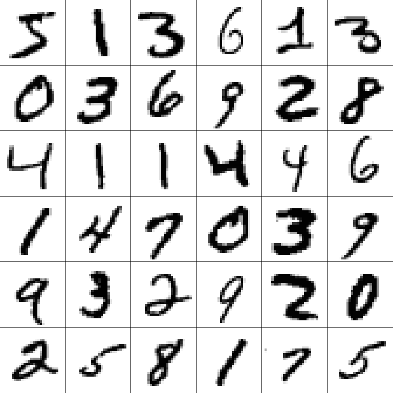

36 Images from MNIST

```r
par(mfcol=c(6,6))
par(mar=c(0, 0, 0, 0), xaxs='i', yaxs='i')
for (idx in 1:36) {
    im <- x_train[idx,,]
    im <- t(apply(im, 2, rev))
    image(1:28, 1:28, 1-im, ann=F, xaxt="n", yaxt="n", col=gray((0:255)/255), main=NULL)
}
```

```r
x_train <- keras::array_reshape(x_train, c(nrow(x_train), 784))
x_test  <- keras::array_reshape(x_test, c(nrow(x_test), 784))
x_train <- x_train/255
x_test  <- x_test/255
y_train_cat <- keras::to_categorical(y_train, 10)
y_test_cat  <- keras::to_categorical(y_test, 10)
```

To begin with, let’s go for a naive strategy and run a PCA analysis on the input training samples to see how they cluster.

**INCLASS WORK** Reuse the code you already saw in order to run a PCA on the MNIST data set and see how the digits clusters in the first principal components.

```r
# #### YOUR WORK HERE
```

## 3.3 Build your “traditional model”

**INCLASS WORK** Build first a “traditional” neural network, compile and train it the MNIST data set.

```r
#### YOUR WORK HERE
```

Let us now assess the performance of your model using the `evaluate` and `predict` functions.

```r
#### get loss and accuracy on the test set
eval_test <- model %>% evaluate(
    x       = x_test,
    y       = y_test_cat,
    verbose = 0
)
print(paste("Loss on test set:", round(eval_test["loss"], 5), sep=" "))
print(paste("Accuracy on test set:", round(eval_test["accuracy"], 5), sep=" "))

predictedTrain <- model %>% predict(x=x_train) %>% k_argmax()
predictedTest <- model %>% predict(x=x_test) %>% k_argmax()

confMatTrain <- getConfusionMatrix(as.character(predictedTrain), as.character(y_train))
confMatTest <- getConfusionMatrix(as.character(predictedTest), as.character(y_test))

ktrain <- kable(confMatTrain, caption="Train")
ktest <- kable(confMatTest, caption="Test")
kables(list(ktrain, ktest), format="html", caption="Confusion matrices")
```

[output not shown]

```r
mnist   <- keras::dataset_mnist()
x_train <- mnist$train$x          # 3d array (60000,28,28)
y_train <- mnist$train$y          # 1d array (60000)

x_test  <- mnist$test$x           # 3d array (10000,28,28)
y_test  <- mnist$test$y           # 1d array (60000)

x_train <- x_train/255
x_test  <- x_test/255

x_train <- array_reshape(x_train, c(nrow(x_train), 28, 28, 1)) # 4d array (60000, 28, 28, 1)
x_test <- array_reshape(x_test, c(nrow(x_test), 28, 28, 1)) # 4d array (60000, 28, 28, 1)

y_train_cat <- keras::to_categorical(y_train, 10)
y_test_cat  <- keras::to_categorical(y_test, 10)
```

## 3.4 Build your CNN model

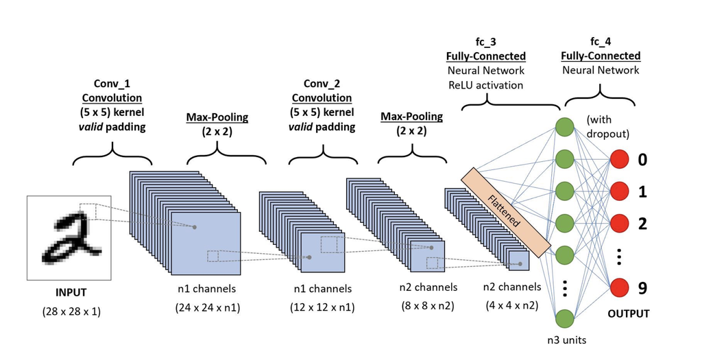

**INCLASS WORK** Build the convolutional neural network displayed in the image above, compile and train it the MNIST data set. Has your performance improved?

```r
#### YOUR WORK HER
n1=4
n2=10

model2 <- keras_model_sequential()

model2 %>%
layer_conv_2d(filters = 32,kernel_size = c(5,5), input_shape = c(28,28,1), activation = 'relu') %>%
layer_max_pooling_2d(pool_size = c(2, 2)) %>%
layer_conv_2d(filters = 64,kernel_size = c(5,5), activation = 'relu') %>%
layer_max_pooling_2d(pool_size = c(2, 2)) %>%
layer_flatten() %>%
layer_dense(units = 128, activation = "relu") %>%
layer_dropout(rate = 0.5) %>%
layer_dense(units = 10, activation = "softmax")

model2 %>% compile(optimizer = 'adam', loss = 'categorical_crossentropy', metrics = c('accuracy'))

y_train = to_categorical(y_train, num_classes = 10)

model2 %>% fit(x_train,y_train, epochs = 10,validation_split=0.2)
```

```r
predictedTrain <- model %>% predict(x=x_train) %>% k_argmax()
predictedTest <- model %>% predict(x=x_test) %>% k_argmax()

confMatTrain <- getConfusionMatrix(as.character(predictedTrain), as.character(y_train))
confMatTest <- getConfusionMatrix(as.character(predictedTest), as.character(y_test))

ktrain <- kable(confMatTrain, caption="Train")
ktest <- kable(confMatTest, caption="Test")
kables(list(ktrain, ktest), format="html", caption="Confusion matrices")
```

[output not shown]